# High-dimensional cytometry analysis

Example report: B-cell receptor stimulation in human blood cells (mass cytometry)

Published

November 13, 2026

**Note**

**This is a portfolio example built on public data.** The same workflow applies to conventional and spectral flow cytometry: compensation-corrected or unmixed data, quality control, transformation, gating or clustering, cell-type annotation, and statistics on population sizes and marker levels across conditions.

```r
suppressPackageStartupMessages({
  library(CATALYST); library(diffcyt); library(SingleCellExperiment); library(ggplot2); library(dplyr); library(knitr)
})
theme_set(theme_minimal(base_size = 12))
data(PBMC_fs, PBMC_panel, PBMC_md, merging_table)
sce <- prepData(PBMC_fs, PBMC_panel, PBMC_md, features = PBMC_panel$fcs_colname, transform = TRUE, cofactor = 5)
set.seed(1234)
sce <- cluster(sce, features = "type", xdim = 10, ydim = 10, maxK = 20, seed = 1234, verbose = FALSE)
sce <- mergeClusters(sce, k = "meta20", table = merging_table, id = "merging1")
n_cells <- ncol(sce); n_samples <- length(unique(sce$sample_id))
type_m <- rownames(sce)[rowData(sce)$marker_class == "type"]; state_m <- rownames(sce)[rowData(sce)$marker_class == "state"]
ei <- ei(sce)
design <- createDesignMatrix(ei, cols_design = c("condition", "patient_id"))
contrast <- createContrast(c(0, 1, rep(0, ncol(design) - 2)))
da <- diffcyt(sce, clustering_to_use = "merging1", analysis_type = "DA", method_DA = "diffcyt-DA-edgeR", design = design, contrast = contrast, verbose = FALSE)
da_tab <- as.data.frame(rowData(da$res)) |> arrange(p_adj)
ds <- diffcyt(sce, clustering_to_use = "merging1", analysis_type = "DS", method_DS = "diffcyt-DS-limma", design = design, contrast = contrast, verbose = FALSE)
ds_tab <- as.data.frame(rowData(ds$res)) |> arrange(p_adj)
n_sig <- sum(ds_tab$p_adj < 0.05, na.rm = TRUE)
b <- ds_tab |> filter(grepl("^B-cells", cluster_id)) |> group_by(marker_id) |> slice_min(p_adj, n = 1, with_ties = FALSE) |> ungroup() |> arrange(p_adj) |> slice_head(n = 6)
```

## Summary

- **Design:** blood cells (PBMCs) from four donors, each left unstimulated or stimulated through the B-cell receptor (BCR/Fc cross-linking), measured by mass cytometry. Paired by donor. Data: Bodenmiller et al., *Nature Biotechnology* 2012, as packaged in Bioconductor `CATALYST`.
- **Size:** 5,428 cells from 8 samples; 10 lineage markers used to identify cell types and 14 signaling (phospho-protein) markers measured as readouts.
- **Cell types:** unsupervised clustering (FlowSOM) followed by annotation gave 8 populations: B-cells IgM-, B-cells IgM+, CD4 T-cells, CD8 T-cells, DC, monocytes, NK cells, surface- (“surface-” = cells low for every lineage marker).
- **Results:** 5 populations changed in size and 19 population-marker pairs changed in signaling at FDR below 5%. In B cells, the population that BCR cross-linking acts on directly, the strongest signaling changes were in pNFkB, pp38, pBtk; these serve as the positive control.

## Quality control

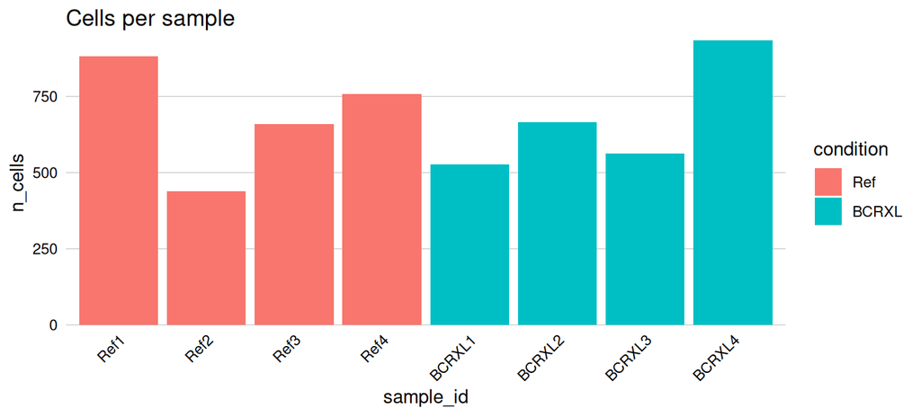

```r
plotCounts(sce, group_by = "sample_id", color_by = "condition") + labs(title = "Cells per sample")
```

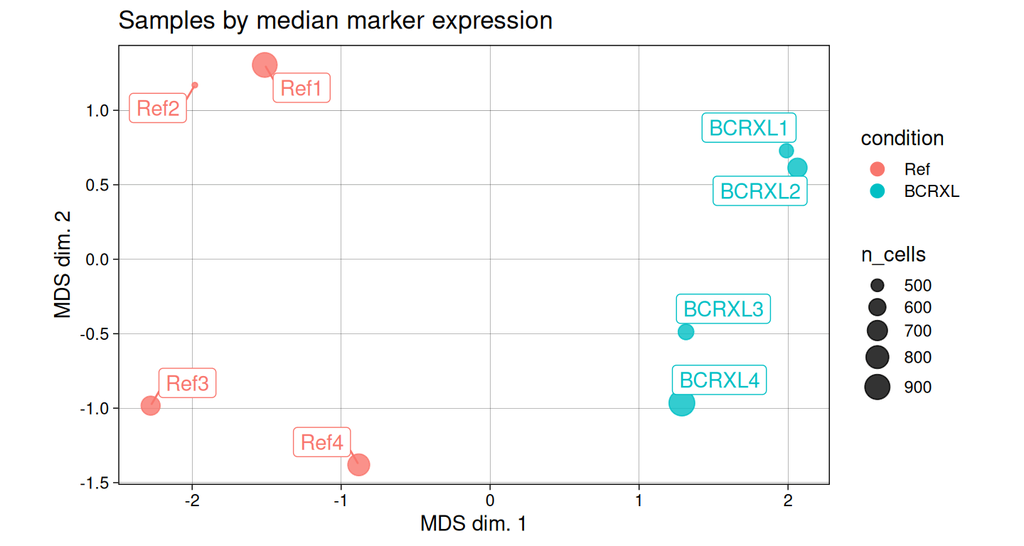

```r
pbMDS(sce, color_by = "condition", label_by = "sample_id") + labs(title = "Samples by median marker expression")
```

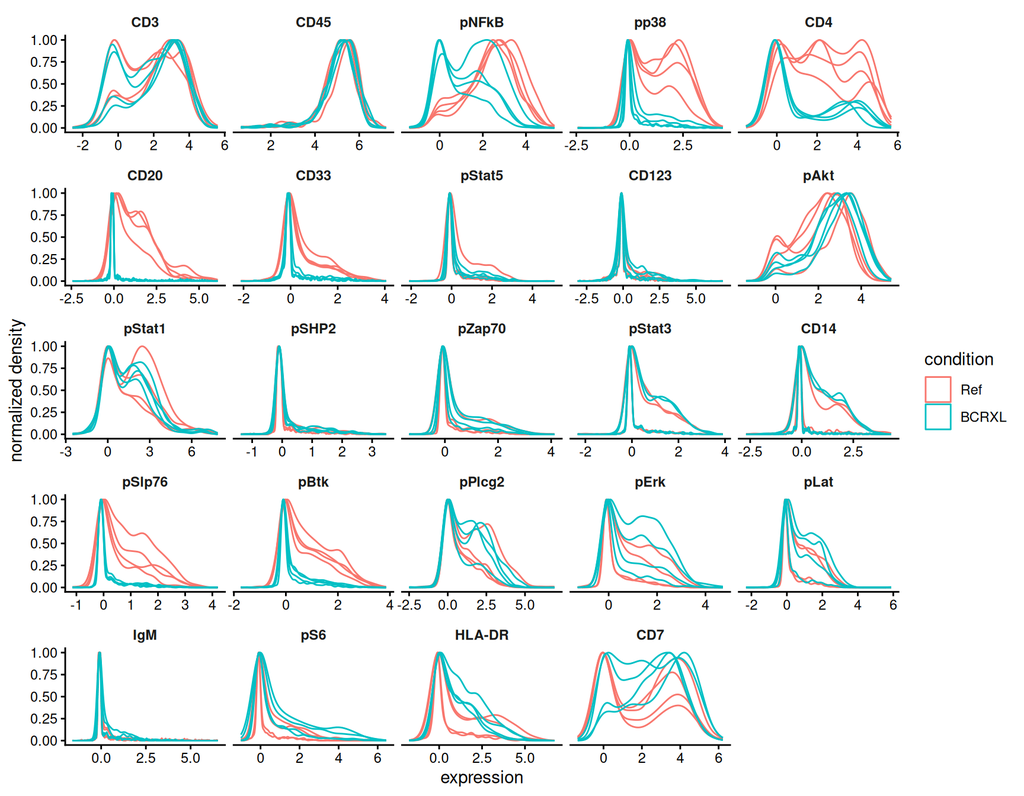

```r
plotExprs(sce, color_by = "condition")
```

Marker distributions look as expected after arcsinh transformation (cofactor 5), with no sample showing a shifted or truncated channel.

## Cell populations

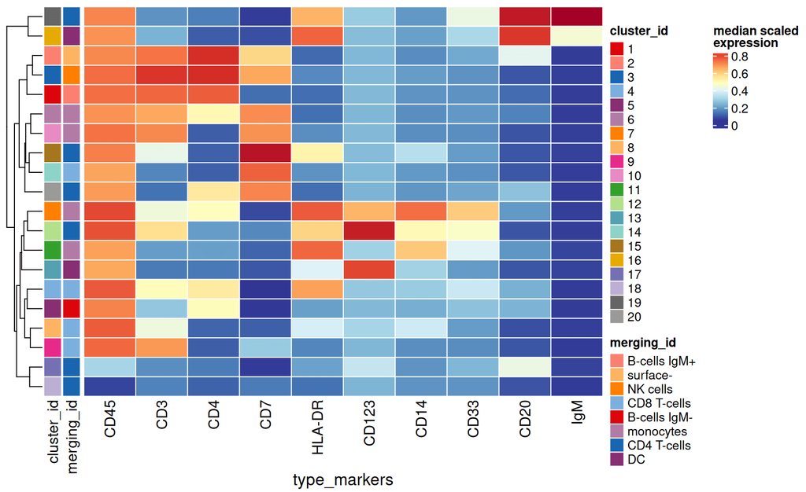

```r
plotExprHeatmap(sce, features = "type", by = "cluster_id", k = "meta20", m = "merging1", scale = "first", q = 0.01, perc = TRUE, col_dend = FALSE)
```

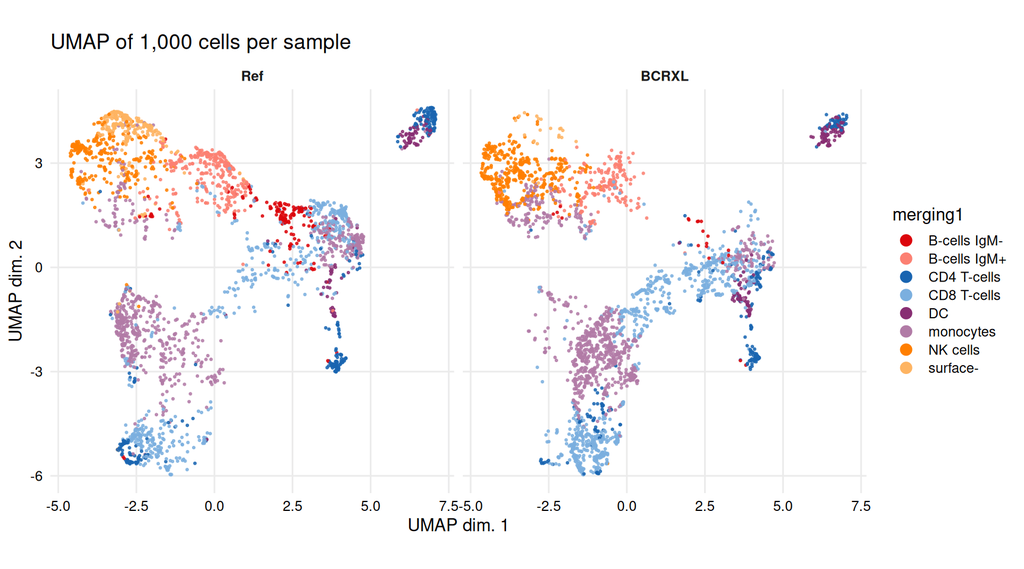

```r
set.seed(1234)
sce <- runDR(sce, "UMAP", cells = 1000, features = "type")
plotDR(sce, "UMAP", color_by = "merging1", facet_by = "condition") + labs(title = "UMAP of 1,000 cells per sample")
```

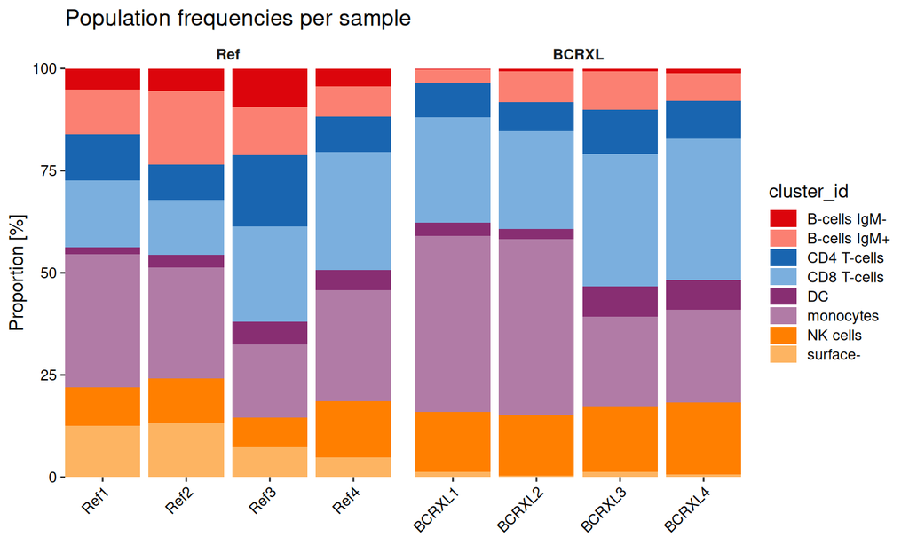

```r
plotAbundances(sce, k = "merging1", by = "sample_id", group_by = "condition") + labs(title = "Population frequencies per sample")
```

## Differential abundance: do population sizes change?

```r
kable(da_tab |> transmute(Population = cluster_id, `log2 fold change` = round(logFC, 2), `Adjusted p` = formatC(p_adj, format = "e", digits = 1),
                          `FDR < 5%` = ifelse(p_adj < 0.05, "yes", "")), row.names = FALSE, align = "lrrc")
```

| Population | log2 fold change | Adjusted p | FDR < 5% |
| --- | --- | --- | --- |
| surface- | -3.37 | 5.6e-25 | yes |
| B-cells IgM- | -3.00 | 9.1e-18 | yes |
| B-cells IgM+ | -0.81 | 1.2e-03 | yes |
| NK cells | 0.63 | 7.3e-03 | yes |
| CD8 T-cells | 0.54 | 1.2e-02 | yes |
| DC | 0.42 | 1.6e-01 |  |
| CD4 T-cells | -0.32 | 1.7e-01 |  |
| monocytes | 0.27 | 1.7e-01 |  |

Population sizes were compared between stimulated and unstimulated samples with a negative-binomial model (edgeR, via diffcyt) adjusting for donor. Short stimulations rarely create or remove cells, so size changes like the drop in IgM-negative B cells usually mean stimulation changed a marker used to define the population (here, surface IgM after B-cell receptor cross-linking), moving cells between clusters. In a client report these are flagged for discussion rather than reported as biology.

## Differential state: does signaling change within each population?

```r
kable(head(ds_tab |> transmute(Population = cluster_id, Marker = marker_id, `log2 fold change` = round(logFC, 2),
                               `Adjusted p` = formatC(p_adj, format = "e", digits = 1)), 15), row.names = FALSE, align = "llrr")
```

| Population | Marker | log2 fold change | Adjusted p |
| --- | --- | --- | --- |
| B-cells IgM+ | pNFkB | -1.98 | 3.4e-03 |
| CD8 T-cells | pNFkB | -1.88 | 3.4e-03 |
| monocytes | pNFkB | -1.50 | 3.4e-03 |
| B-cells IgM+ | pp38 | -1.66 | 3.4e-03 |
| monocytes | pp38 | -1.07 | 3.4e-03 |
| CD8 T-cells | pBtk | -0.51 | 3.4e-03 |
| monocytes | pBtk | -0.65 | 3.4e-03 |
| DC | pS6 | 2.46 | 3.4e-03 |
| monocytes | pSlp76 | -0.61 | 6.5e-03 |
| NK cells | pp38 | -1.06 | 8.9e-03 |
| CD4 T-cells | pBtk | -0.75 | 1.0e-02 |
| B-cells IgM+ | pBtk | -0.44 | 1.1e-02 |
| CD4 T-cells | pNFkB | -1.05 | 1.3e-02 |
| CD8 T-cells | pp38 | -1.27 | 1.3e-02 |
| CD4 T-cells | pp38 | -0.81 | 2.0e-02 |

19 of 112 population-marker pairs changed at FDR below 5% (limma on per-sample medians, donor-paired). The table shows the 15 strongest.

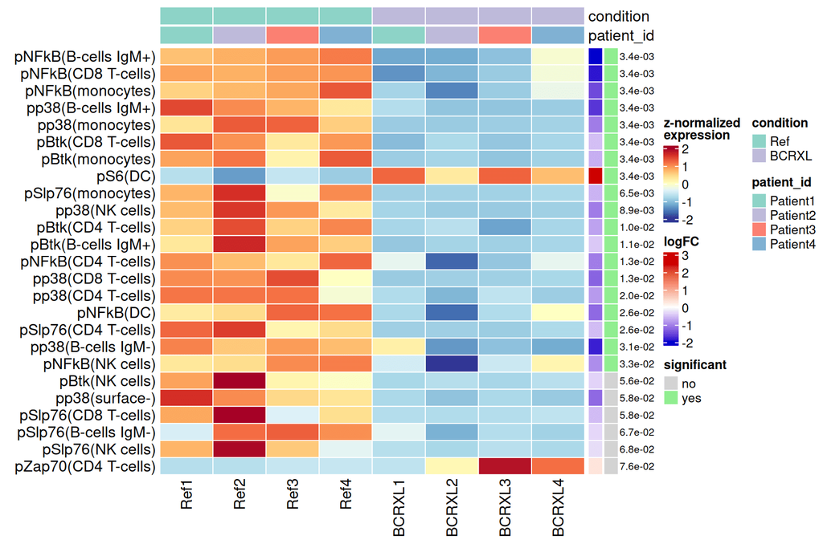

```r
plotDiffHeatmap(sce, rowData(ds$res), all = TRUE, top_n = 25, fdr = 0.05)
```

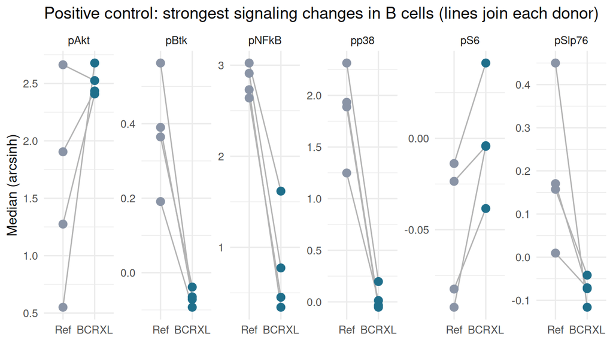

```r
med <- data.frame(t(assay(sce, "exprs")[as.character(b$marker_id), grepl("^B-cells", cluster_ids(sce, "merging1"))]),
                  sample_id = sce$sample_id[grepl("^B-cells", cluster_ids(sce, "merging1"))], check.names = FALSE) |>
  tidyr::pivot_longer(-sample_id, names_to = "marker", values_to = "x") |> group_by(sample_id, marker) |> summarise(median = median(x), .groups = "drop") |>
  left_join(as.data.frame(ei), by = "sample_id")
ggplot(med, aes(condition, median, group = patient_id)) + geom_line(color = "grey70") + geom_point(aes(color = condition), size = 3) +
  facet_wrap(~ marker, scales = "free_y", nrow = 1) + scale_color_manual(values = c(Ref = "#8a94a6", BCRXL = "#1f6f8b")) +
  labs(x = NULL, y = "Median (arcsinh)", color = NULL, title = "Positive control: strongest signaling changes in B cells (lines join each donor)") + theme(legend.position = "none")
```

## Methods (ready to paste into a manuscript)

> Mass cytometry data from peripheral blood mononuclear cells of four donors, unstimulated or stimulated by B-cell receptor/Fc receptor cross-linking (Bodenmiller et al. 2012), were analyzed in R 4.6.2 with CATALYST (v1.36.0). Intensities were arcsinh-transformed with a cofactor of 5. Cells were clustered on 10 lineage markers with FlowSOM (10 × 10 grid) and ConsensusClusterPlus metaclustering (k = 20); metaclusters were annotated into cell populations by their marker profiles. UMAP was computed on 1,000 cells per sample for visualization. Differential abundance was tested with diffcyt-DA-edgeR and differential marker expression with diffcyt-DS-limma on per-sample medians (v1.32.1), using a design with condition and donor; p-values were adjusted by Benjamini–Hochberg and FDR < 0.05 was considered significant.

## Deliverables in a client project

- This report (HTML and PDF) and every figure as high-resolution PNG and vector PDF
- Population frequency and median-intensity tables per sample (Excel and CSV)
- For gated flow cytometry: a gating hierarchy with the gates drawn on each sample, or a FlowJo-compatible workspace
- Analysis code to reproduce every number, and a 30-minute call to review the results